# Report

Nhat Tung Le, Id 426246

2023-01-26

In accordance with the Honor Code, I certify that my answers here are my own work, and I did not make my solutions available to anyone else.

## 1.Introduction

We are considering a European style down-and-out call option with a barrier active between the moment of pricing and the option expiry.

In this project, I try to create an Rcpp package which provides a function returning the Monte Carlo approximation of the option theoretical price.

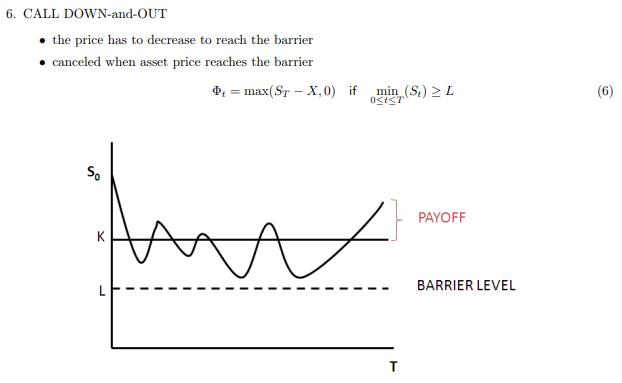

## 2.Coding

### 2.1. Create a package using Rcpp

With RStudio, we can easily create packages using Rcpp. The following figure is the folder structure in my project, where the .cpp files will be stored in the **src** folder.

[figure not shown]

### 2.2. Libraries

In this project I reused the code from the lecturer, with the “getOneGaussianByBoxMueller” method, the goal was to get a random value. In addition, I also use some basic libraries from C++.

The structure of the files related to C++ is as shown below:

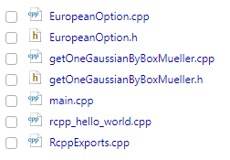

### 2.3. Sources

In this project, I use object-oriented programming. First I built the interface “EuropeanOption”, then I re-implemented the necessary methods.

Attributes include:

- S_: the initial stock price S_0
- K_: strike price
- sigma_: annualized volatility rate
- r_: annualized risk-free rate
- t_: time to maturity
- L: barrier level

```
#include<vector>

class EuropeanOption{

public:
  //constructor
  // S_: the initial stock price S_0
  // K_: strike price
  // sigma_: annualized volatility rate
  // r_: annualized risk-free rate
  // t_: time to maturity
  // L: barrier level
  EuropeanOption(double S_,
                 double K_,
                 double r_,
                 double sigma_,
                 double L_,
                 double t_,
                 int NumberOfPaths_
  );

  // method
  double getDownAndOutCall();

  //members
  double S;
  double K;
  double r;
  double sigma;
  double L;
  double t;
  int NumberOfPaths;
};
```

In the file EuropeanOption.cpp, I re-implemented all the necessary methods.

- Constructor method helps us to create new object from class.

```
//definition of constructor
EuropeanOption::EuropeanOption(double S_,
                               double K_,
                               double r_,
                               double sigma_,
                               double L_,
                               double t_,
                               int NumberOfPaths_){
      S = S_;
      K = K_;
      r = r_;
      sigma = sigma_;
      L = L_;
      t = t_;
      NumberOfPaths = NumberOfPaths_;
}
```

- Method getDownAndOutCall()

```
double EuropeanOption::getDownAndOutCall(){
  double variance = sigma * sigma * S;
  double rootVariance = sqrt(variance);
  double itoCorrection = -0.5 * variance;
  double movedSpot = S * exp(r * t + itoCorrection);
  double thisSpot;
  double runningSum = 0;

  for (int i = 0; i < NumberOfPaths; i++) {
    double thisGaussian = getOneGaussianByBoxMueller();
    thisSpot = movedSpot * exp(rootVariance * thisGaussian);

    if (thisSpot <= L) {
        double thisPayoff = 0;
        runningSum+=thisPayoff;
    }else{
        double thisPayoff = thisSpot - K;
        runningSum+=thisPayoff>0?thisPayoff:0;
    }

  }


  double mean = runningSum / NumberOfPaths;
  mean = mean * exp(-r * t);
  return mean;
}
```

The function uses a for loop to simulate the price of the underlying asset over a specified number of paths (NumberOfPaths).

For each path, it generates a random value using the **getOneGaussianByBoxMueller()** function, which presumably generates a random value from a normal distribution. This random value is then used to calculate the simulated price of the underlying asset at the end of the path (thisSpot) using the formula: **thisSpot = movedSpot * exp(rootVariance * thisGaussian)**

After simulating the price of the underlying asset, the code checks whether the simulated price is **less than or equal to the barrier (L)**. If it is, the payoff for that path is 0. If it is not, the payoff is the maximum of the difference between the simulated price and the strike price (K) and 0.

Finally, the function calculates the mean of the payoffs, discounts it by the risk-free interest rate and returns the mean as the estimated value of the option.

- R-export

In the main file, I build a getDownAndOutCall method, and specify it with the note: “// [[Rcpp::export]]”, this helps R understand the methods to be exported.

```
#include<Rcpp.h>
#include<vector>
#include<ctime>
#include<cstdlib>
#include"EuropeanOption.h"
#include"getOneGaussianByBoxMueller.h"

using namespace Rcpp;
using namespace std;

// [[Rcpp::export]]
double getDownAndOutCall(double S_      = 95,
                         double K_      = 100,
                         double r_      = 0.07,
                         double sigma_  = 0.24,
                         double L_      = 80,
                         double t_      = 0.75,
                         int NumberOfPaths_ = 1000){

  EuropeanOption europeanOption(S_, K_, r_, sigma_, L_, t_, NumberOfPaths_);

  double result =  europeanOption.getDownAndOutCall();

  return result;
}
```

## 3.Building and Testing

### 3.1. Building

The statement **Rcpp::compileAttributes()** will help us generated the necessary code before building the project.

With the RStudio tool, you can build the project as “source” or “win.binary”. I have experimented with these two options.

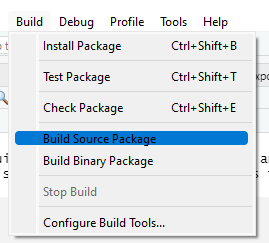

The package built as suore will be named “FileName_version.tar.zip”, the package built as a binary is named “FileName_version.zip”.

### 3.2. Testing

```r
# loading packages
library(tidyverse)
library(inline) # allows to use C++ inline - within R code
library(Rcpp)   # Rccp package by Dirk Eddelbuettel
library(xts)
library(dygraphs)

setwd("C:/Users/Windows/OneDrive/Learning/WNE/SEM3/ApplyFinace/Lab3And4/")
list.files()


# install.packages("montecarlo426246_1.0.tar.zip",
#                  type = "source",
#                  repos = NULL)

install.packages("montecarlo426246_1.0.zip",
                 type = "source",
                 repos = NULL)

x <- montecarlo426246::getDownAndOutCall(S_      = 95,
                                         K_      = 100,
                                         r_      = 0.07,
                                         sigma_  = 0.24,
                                         L_      = 80,
                                         t_      = 0.75,
                                         NumberOfPaths_ = 1000)

print(x)
```

Result:

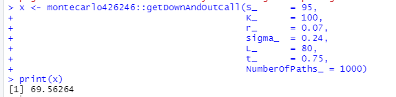

## 4.Conclustion

Through this project, I reviewed my knowledge of option pricing with Monte Carlo. I also know basic C++ programming, especially object-oriented programming. I also learned how to use C++ in R, and how to build new library packages.

Although I do not have much experience in the financial field, I find that the knowledge in this exercise will help me in simulating data series in the upcoming problems.

Finally, I would like to thank **Prof. Paweł Sakowski**, who led the labs and shared his knowledge in this module.

================================================================================